# Ejercicios de inferencia

David Cáceres

24/3/2022

## Ejercicios del libro de Faraway

### 1. (Ejercicio 1 cap. 3 pág. 48)

### For the prostate data, fit a model with lpsa as the response and the other variables as predictors:

#### (a) Compute 90 and 95% CIs for the parameter associated with age. Using just these intervals,

what could we have deduced about the p-value for age in the regression summary?

```r
require(faraway)
lmod<-lm(lpsa ~ lcavol + lweight + age + lbph + svi + lcp + gleason + pgg45,  data = prostate)
summary(lmod)
```

```
##
## Call:
## lm(formula = lpsa ~ lcavol + lweight + age + lbph + svi + lcp +
##     gleason + pgg45, data = prostate)
##
## Residuals:
##     Min      1Q  Median      3Q     Max
## -1.7331 -0.3713 -0.0170  0.4141  1.6381
##
## Coefficients:
##              Estimate Std. Error t value Pr(>|t|)
## (Intercept)  0.669337   1.296387   0.516  0.60693
## lcavol       0.587022   0.087920   6.677 2.11e-09 ***
## lweight      0.454467   0.170012   2.673  0.00896 **
## age         -0.019637   0.011173  -1.758  0.08229 .
## lbph         0.107054   0.058449   1.832  0.07040 .
## svi          0.766157   0.244309   3.136  0.00233 **
## lcp         -0.105474   0.091013  -1.159  0.24964
## gleason      0.045142   0.157465   0.287  0.77503
## pgg45        0.004525   0.004421   1.024  0.30886
## ---
## Signif. codes:  0 '***' 0.001 '**' 0.01 '*' 0.05 '.' 0.1 ' ' 1
##
## Residual standard error: 0.7084 on 88 degrees of freedom
## Multiple R-squared:  0.6548, Adjusted R-squared:  0.6234
## F-statistic: 20.86 on 8 and 88 DF,  p-value: < 2.2e-16
```

```r
confint(lmod, level=.90)
```

```
##                      5 %         95 %
## (Intercept) -1.485718237  2.824391633
## lcavol       0.440867156  0.733176497
## lweight      0.171846568  0.737088281
## age         -0.038210200 -0.001064151
## lbph         0.009890745  0.204217317
## svi          0.360029029  1.172285623
## lcp         -0.256770899  0.045822373
## gleason     -0.216620186  0.306903382
## pgg45       -0.002824333  0.011874796
```

```r
# Vemos que para age (age         -0.038210200 -0.001064151)
```

```r
confint(lmod, level=.95)
```

```
##                    2.5 %      97.5 %
## (Intercept) -1.906960983 3.245634379
## lcavol       0.412298699 0.761744954
## lweight      0.116603435 0.792331414
## age         -0.041840618 0.002566267
## lbph        -0.009101499 0.223209561
## svi          0.280644232 1.251670420
## lcp         -0.286344443 0.075395916
## gleason     -0.267786053 0.358069248
## pgg45       -0.004260932 0.013311395
```

```r
# age         -0.041840618 0.002566267
```

Vemos que el intervalo de confianza del 90% no incluye el 0, cosa que si pasa en el intervalo del 95%. Lo cual nos indica que el parámetro age no puede ser 0 para un significación del 10%.

#### (b) Compute and display a 95% joint confidence region for the parameters associated with age and lbph. Plot the origin on this display. The location of the origin on the display tells us the outcome of a certain hypothesis test. State that test and its outcome.

Necesitamos el paquete ellipse para representar la región de confianza.

```r
require(ellipse)
```

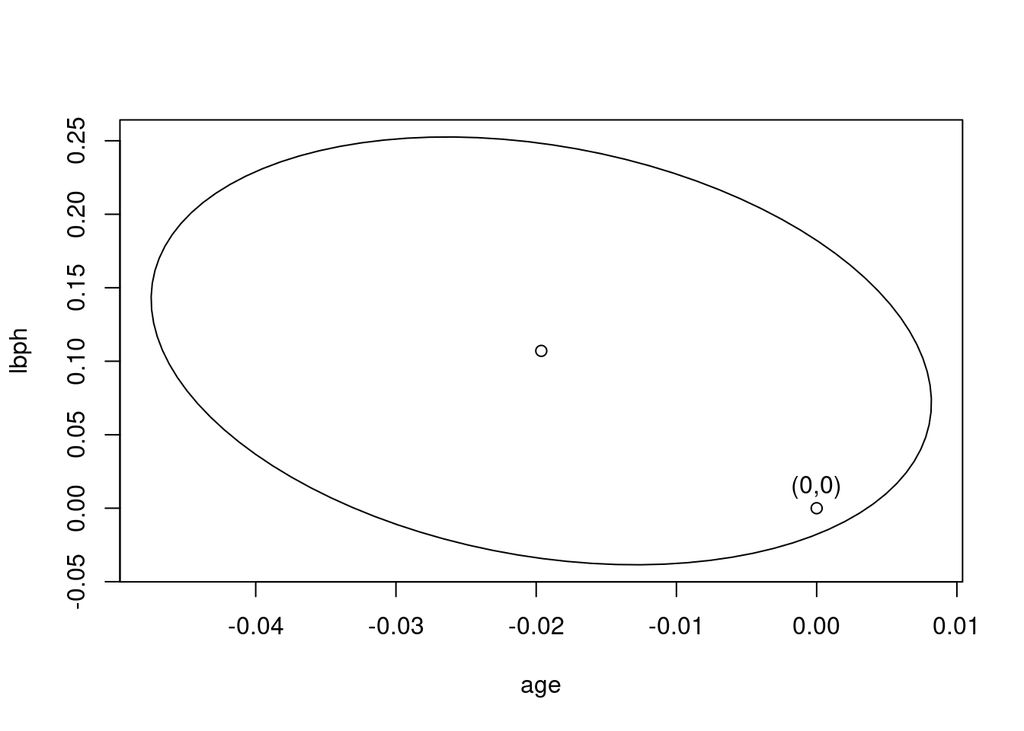

```r
plot(ellipse(lmod,c(4,5)), type="l")
points(coef(lmod)[4], coef(lmod)[5])
points(0,0)
text(0,0, labels="(0,0)", pos = 3)
```

El punto 0,0 que es el equivalente a la hipótesis nula de beta = 0 para las dos variables. Vemos que está dentro del intervalo de confianza, así que se acepta.

#### (c) In the text, we made a permutation test corresponding to the F -test for the significance of all the predictors. Execute the permutation test corresponding to the t-test for age in this model. (Hint: summary(g)$coef[4,3] gets you the t-statistic you need if the model is called g.)

El contraste de hipótesis sería

Ho: β age = 0 H1: β age ≠ 0

```r
set.seed(123)
nreps<- 4000
tstats <- numeric(nreps)

for(i in 1:nreps){
lmod1<-lm(lpsa ~ lweight + sample(age) + lbph + svi + lcp + gleason + pgg45, data= prostate)
tstats[i] <- summary(lmod1)$coef[4,3]
}

mean(abs(tstats) > abs(summary(lmod)$coef[4,3]))
```

```
## [1] 0.00025
```

#### (d) Remove all the predictors that are not significant at the 5% level. Test this model against the original model. Which model is preferred?

```r
confint(lmod, level=.90)
```

```
##                      5 %         95 %
## (Intercept) -1.485718237  2.824391633
## lcavol       0.440867156  0.733176497
## lweight      0.171846568  0.737088281
## age         -0.038210200 -0.001064151
## lbph         0.009890745  0.204217317
## svi          0.360029029  1.172285623
## lcp         -0.256770899  0.045822373
## gleason     -0.216620186  0.306903382
## pgg45       -0.002824333  0.011874796
```

```r
lmod2<- lm(lpsa ~ lcavol + lweight + svi, data = prostate)
summary(lmod2)
```

```
##
## Call:
## lm(formula = lpsa ~ lcavol + lweight + svi, data = prostate)
##
## Residuals:
##      Min       1Q   Median       3Q      Max
## -1.72964 -0.45764  0.02812  0.46403  1.57013
##
## Coefficients:
##             Estimate Std. Error t value Pr(>|t|)
## (Intercept) -0.26809    0.54350  -0.493  0.62298
## lcavol       0.55164    0.07467   7.388  6.3e-11 ***
## lweight      0.50854    0.15017   3.386  0.00104 **
## svi          0.66616    0.20978   3.176  0.00203 **
## ---
## Signif. codes:  0 '***' 0.001 '**' 0.01 '*' 0.05 '.' 0.1 ' ' 1
##
## Residual standard error: 0.7168 on 93 degrees of freedom
## Multiple R-squared:  0.6264, Adjusted R-squared:  0.6144
## F-statistic: 51.99 on 3 and 93 DF,  p-value: < 2.2e-16
```

Para ver cual de los dos modelos es mejor, realizamos un anova para constrastar la hipótesis nula.

```r
anova(lmod2, lmod)
```

```
## Analysis of Variance Table
##
## Model 1: lpsa ~ lcavol + lweight + svi
## Model 2: lpsa ~ lcavol + lweight + age + lbph + svi + lcp + gleason +
##     pgg45
##   Res.Df    RSS Df Sum of Sq      F Pr(>F)
## 1     93 47.785
## 2     88 44.163  5    3.6218 1.4434 0.2167
```

La diferencia entre ambos es muy poco significativa, así que optamos por el modelo más simple.

### 2. (Ejercicio 2 cap. 3 pág. 49)

Thirty samples of cheddar cheese were analyzed for their content of acetic acid, hydrogen sulfide and lactic acid. Each sample was tasted and scored by a panel of judges and the average taste score produced. Use the cheddar data to answer the following:

#### (a) Fit a regression model with taste as the response and the three chemical contents as predictors. Identify the predictors that are statistically significant at the 5% level.

```r
# modelo

lmod3<- lm(taste ~ Acetic + H2S + Lactic, data = cheddar)
summary(lmod3)
```

```
##
## Call:
## lm(formula = taste ~ Acetic + H2S + Lactic, data = cheddar)
##
## Residuals:
##     Min      1Q  Median      3Q     Max
## -17.390  -6.612  -1.009   4.908  25.449
##
## Coefficients:
##             Estimate Std. Error t value Pr(>|t|)
## (Intercept) -28.8768    19.7354  -1.463  0.15540
## Acetic        0.3277     4.4598   0.073  0.94198
## H2S           3.9118     1.2484   3.133  0.00425 **
## Lactic       19.6705     8.6291   2.280  0.03108 *
## ---
## Signif. codes:  0 '***' 0.001 '**' 0.01 '*' 0.05 '.' 0.1 ' ' 1
##
## Residual standard error: 10.13 on 26 degrees of freedom
## Multiple R-squared:  0.6518, Adjusted R-squared:  0.6116
## F-statistic: 16.22 on 3 and 26 DF,  p-value: 3.81e-06
```

Por debajo de 0.05 se encuentran H2S y Lactic. Estos serían estadísticamente significativos para ese intervalo.

#### (b) Acetic and H2S are measured on a log scale. Fit a linear model where all three predictors are measured on their original scale. Identify the predictors that are statistically significant at the 5% level for this model.

```r
lmod4<-lm(taste ~ I(exp(Acetic)) + I(exp(H2S)) + Lactic, data=cheddar)
summary(lmod4)
```

```
##
## Call:
## lm(formula = taste ~ I(exp(Acetic)) + I(exp(H2S)) + Lactic, data = cheddar)
##
## Residuals:
##     Min      1Q  Median      3Q     Max
## -16.209  -7.266  -1.651   7.385  26.335
##
## Coefficients:
##                  Estimate Std. Error t value Pr(>|t|)
## (Intercept)    -1.897e+01  1.127e+01  -1.684   0.1042
## I(exp(Acetic))  1.891e-02  1.562e-02   1.210   0.2371
## I(exp(H2S))     7.668e-04  4.188e-04   1.831   0.0786 .
## Lactic          2.501e+01  9.062e+00   2.760   0.0105 *
## ---
## Signif. codes:  0 '***' 0.001 '**' 0.01 '*' 0.05 '.' 0.1 ' ' 1
##
## Residual standard error: 11.19 on 26 degrees of freedom
## Multiple R-squared:  0.5754, Adjusted R-squared:  0.5264
## F-statistic: 11.75 on 3 and 26 DF,  p-value: 4.746e-05
```

Tan solo el ácido láctico parece significativo al 5%.

#### (c) Can we use an F -test to compare these two models? Explain. Which model provides a better fit to the data? Explain your reasoning.

Para poder usar el F test, todas las variables de uno de los modelos tienen que estar presentes en el otro. En este caso, tenemos variables distintas ya que en un modelo se expresan de forma logarítmica. No pueden compararse y usar el F test.

#### (d) If H2S is increased 0.01 for the model used in (a), what change in the taste would be expected?

```r
3.9118 * 0.01
```

```
## [1] 0.039118
```

#### (e) What is the percentage change in H2S on the original scale corresponding to an additive increase of 0.01 on the (natural) log scale?

### 3. (Ejercicio 3 cap. 3 pág. 49)

Using the teengamb data, fit a model with gamble as the response and the other variables as predictors.

```r
require(faraway)
data(teengamb)
head(teengamb)
```

```
##   sex status income verbal gamble
## 1   1     51   2.00      8    0.0
## 2   1     28   2.50      8    0.0
## 3   1     37   2.00      6    0.0
## 4   1     28   7.00      4    7.3
## 5   1     65   2.00      8   19.6
## 6   1     61   3.47      6    0.1
```

```r
lmod5<-lm(gamble ~ sex + status + income + verbal, data = teengamb)
```

#### (a) Which variables are statistically significant at the 5% level?

```r
summary(lmod5)
```

```
##
## Call:
## lm(formula = gamble ~ sex + status + income + verbal, data = teengamb)
##
## Residuals:
##     Min      1Q  Median      3Q     Max
## -51.082 -11.320  -1.451   9.452  94.252
##
## Coefficients:
##              Estimate Std. Error t value Pr(>|t|)
## (Intercept)  22.55565   17.19680   1.312   0.1968
## sex         -22.11833    8.21111  -2.694   0.0101 *
## status        0.05223    0.28111   0.186   0.8535
## income        4.96198    1.02539   4.839 1.79e-05 ***
## verbal       -2.95949    2.17215  -1.362   0.1803
## ---
## Signif. codes:  0 '***' 0.001 '**' 0.01 '*' 0.05 '.' 0.1 ' ' 1
##
## Residual standard error: 22.69 on 42 degrees of freedom
## Multiple R-squared:  0.5267, Adjusted R-squared:  0.4816
## F-statistic: 11.69 on 4 and 42 DF,  p-value: 1.815e-06
```

Tan solo el sexo, y los ingresos.

#### (b) What interpretation should be given to the coefficient for sex?

El coeficiente mide cuanto varía la variable respuesta por cada unidad de la variable explicativa. En este caso, sex es una variable cualitativa y se expresa en 0 para el hombre y 1 para la mujer. EL valor es de -22.118, lo cual siginifica que al pasar de 0 a 1, o de hombre a mujer, el dinero dedicado al juego (gamble), se reduce en 22.118 libras.

#### (c) Fit a model with just income as a predictor and use an F -test to compare it to the full model.

```r
lmod6<- lm(gamble ~ income, data = teengamb)
summary(lmod6)
```

```
##
## Call:
## lm(formula = gamble ~ income, data = teengamb)
##
## Residuals:
##     Min      1Q  Median      3Q     Max
## -46.020 -11.874  -3.757  11.934 107.120
##
## Coefficients:
##             Estimate Std. Error t value Pr(>|t|)
## (Intercept)   -6.325      6.030  -1.049      0.3
## income         5.520      1.036   5.330 3.05e-06 ***
## ---
## Signif. codes:  0 '***' 0.001 '**' 0.01 '*' 0.05 '.' 0.1 ' ' 1
##
## Residual standard error: 24.95 on 45 degrees of freedom
## Multiple R-squared:  0.387,  Adjusted R-squared:  0.3734
## F-statistic: 28.41 on 1 and 45 DF,  p-value: 3.045e-06
```

```r
anova(lmod6, lmod5)
```

```
## Analysis of Variance Table
##
## Model 1: gamble ~ income
## Model 2: gamble ~ sex + status + income + verbal
##   Res.Df   RSS Df Sum of Sq      F  Pr(>F)
## 1     45 28009
## 2     42 21624  3    6384.8 4.1338 0.01177 *
## ---
## Signif. codes:  0 '***' 0.001 '**' 0.01 '*' 0.05 '.' 0.1 ' ' 1
```

El p-valor es de 0.01177, lo cual nos hace rechazar la hipótesis nula de que las demás variables son cero y no influyen en la variable respuesta.

### 4. (Ejercicio 4 cap. 3 pág. 49)

Using the sat data:

```r
data(sat)
head(sat)
```

```
##            expend ratio salary takers verbal math total
## Alabama     4.405  17.2 31.144      8    491  538  1029
## Alaska      8.963  17.6 47.951     47    445  489   934
## Arizona     4.778  19.3 32.175     27    448  496   944
## Arkansas    4.459  17.1 28.934      6    482  523  1005
## California  4.992  24.0 41.078     45    417  485   902
## Colorado    5.443  18.4 34.571     29    462  518   980
```

#### (a) Fit a model with total sat score as the response and expend, ratio and salary as predictors. Test the hypothesis that β salary = 0. Test the hypothesis that. Do any of these predictors have an effect on the response?

```r
lmod7<- lm(total ~ expend + ratio + salary, data = sat)
summary(lmod7)
```

```
##
## Call:
## lm(formula = total ~ expend + ratio + salary, data = sat)
##
## Residuals:
##      Min       1Q   Median       3Q      Max
## -140.911  -46.740   -7.535   47.966  123.329
##
## Coefficients:
##             Estimate Std. Error t value Pr(>|t|)
## (Intercept) 1069.234    110.925   9.639 1.29e-12 ***
## expend        16.469     22.050   0.747   0.4589
## ratio          6.330      6.542   0.968   0.3383
## salary        -8.823      4.697  -1.878   0.0667 .
## ---
## Signif. codes:  0 '***' 0.001 '**' 0.01 '*' 0.05 '.' 0.1 ' ' 1
##
## Residual standard error: 68.65 on 46 degrees of freedom
## Multiple R-squared:  0.2096, Adjusted R-squared:  0.1581
## F-statistic: 4.066 on 3 and 46 DF,  p-value: 0.01209
```

β salary = 0

Vemos en el summary, que el p-valor para esta variable es de 0.0667 para un 5% de significación, lo cual significa que no podemos rechazar la hipótesis nula y que el salario no tiene influencia sobre el total.

β salary = β ratio = β expend = 0

El propio sumary nos da los valores del F test, con un p-valor de 0.01209, lo cual significa que tenemos que rechazar la hipótesis nula. En este caso, y a pesar de que el salario de forma independiente no tiene una influencia significativa, el conjunto de valores si la tiene.

#### (b) Now add takers to the model. Test the hypothesis that β takers = 0. Compare this model to the previous one using an F -test. Demonstrate that the F -test and t-test here are equivalent.

```r
lmod8<- lm(total ~ expend + ratio + salary + takers, data = sat)
summary(lmod8)
```

```
##
## Call:
## lm(formula = total ~ expend + ratio + salary + takers, data = sat)
##
## Residuals:
##     Min      1Q  Median      3Q     Max
## -90.531 -20.855  -1.746  15.979  66.571
##
## Coefficients:
##              Estimate Std. Error t value Pr(>|t|)
## (Intercept) 1045.9715    52.8698  19.784  < 2e-16 ***
## expend         4.4626    10.5465   0.423    0.674
## ratio         -3.6242     3.2154  -1.127    0.266
## salary         1.6379     2.3872   0.686    0.496
## takers        -2.9045     0.2313 -12.559 2.61e-16 ***
## ---
## Signif. codes:  0 '***' 0.001 '**' 0.01 '*' 0.05 '.' 0.1 ' ' 1
##
## Residual standard error: 32.7 on 45 degrees of freedom
## Multiple R-squared:  0.8246, Adjusted R-squared:  0.809
## F-statistic: 52.88 on 4 and 45 DF,  p-value: < 2.2e-16
```

El p-valor para takers es tremendamente bajo, 2.61 e⁻16. Se rechaza la hipótesis nula. Esta variable tendrá efecto sobre la variable respuesta.

```r
anova(lmod7,lmod8)
```

```
## Analysis of Variance Table
##
## Model 1: total ~ expend + ratio + salary
## Model 2: total ~ expend + ratio + salary + takers
##   Res.Df    RSS Df Sum of Sq      F    Pr(>F)
## 1     46 216812
## 2     45  48124  1    168688 157.74 2.607e-16 ***
## ---
## Signif. codes:  0 '***' 0.001 '**' 0.01 '*' 0.05 '.' 0.1 ' ' 1
```

El p-valor es casi idéntico, lo cual demuestra la equivalencia de ambos tests.

## Faraway

### 5. (∗) (Ejercicio 5 cap. 3 pág. 50). Find a formula relating R 2 and the F -test for the regression.

Si la fórmula de F:

F =(T SS − RSS)/(m − 1) / RSS/(n − m)

Y la de R² es:

R² = 1- RSS/TSS , 1 - R^= RSS/TSS

De este modo:

### 6. (∗) (Ejercicio 6 cap. 3 pág. 50). Thirty-nine MBA students were asked about happiness and how this related to their income and social life. The data are found in happy. Fit a regression model with happy as the response and the other four variables as predictors.

```r
data(happy)
head(happy)
```

```
##   happy money sex love work
## 1    10    36   0    3    4
## 2     8    47   1    3    1
## 3     8    53   0    3    5
## 4     8    35   1    3    3
## 5     4    88   1    1    2
## 6     9   175   1    3    4
```

#### (a) Which predictors were statistically significant at the 1% level?

```r
lmod9<-lm(happy ~ money + sex + love + work, data=happy)
fit<-lm(happy ~ ., data=happy)
summary(lmod9)
```

```
##
## Call:
## lm(formula = happy ~ money + sex + love + work, data = happy)
##
## Residuals:
##     Min      1Q  Median      3Q     Max
## -2.7186 -0.5779 -0.1172  0.6340  2.0651
##
## Coefficients:
##              Estimate Std. Error t value Pr(>|t|)
## (Intercept) -0.072081   0.852543  -0.085   0.9331
## money        0.009578   0.005213   1.837   0.0749 .
## sex         -0.149008   0.418525  -0.356   0.7240
## love         1.919279   0.295451   6.496 1.97e-07 ***
## work         0.476079   0.199389   2.388   0.0227 *
## ---
## Signif. codes:  0 '***' 0.001 '**' 0.01 '*' 0.05 '.' 0.1 ' ' 1
##
## Residual standard error: 1.058 on 34 degrees of freedom
## Multiple R-squared:  0.7102, Adjusted R-squared:  0.6761
## F-statistic: 20.83 on 4 and 34 DF,  p-value: 9.364e-09
```

Al 1%, el amor y solo el amor, es estadísticamente significativo.

#### (b) Use the table() function to produce a numerical summary of the response. What assumption used to perform the t-tests seems questionable in light of this summary?

```r
table(happy$happy)
```

```
##
##  2  3  4  5  6  7  8  9 10
##  1  1  4  5  2  8 14  3  1
```

Los valores no muestran una distribución normal

#### (c) Use the permutation procedure described in Section 3.3 to test the significance of the money predictor.

```r
lmod10<-lm(happy ~ sample(money) + sex + love + work, data= happy)

nreps<-4000
tstats<-numeric(nreps)
set.seed(123)
for(i in 1:nreps){
  lmod10<-lm(happy ~ sample(money) + sex + love + work, data= happy)
  tstats[i]<-summary(lmod10)$coef[2,3]
}

mean(abs(tstats) > abs(summary(lmod10)$coef[2,3]))
```

```
## [1] 0.26925
```

```r
summary(lmod10)
```

```
##
## Call:
## lm(formula = happy ~ sample(money) + sex + love + work, data = happy)
##
## Residuals:
##     Min      1Q  Median      3Q     Max
## -3.0537 -0.5646 -0.2142  0.7203  1.9042
##
## Coefficients:
##                Estimate Std. Error t value Pr(>|t|)
## (Intercept)    0.498685   0.941203   0.530   0.5997
## sample(money) -0.005652   0.005059  -1.117   0.2717
## sex            0.050605   0.409453   0.124   0.9024
## love           1.953848   0.304068   6.426 2.42e-07 ***
## work           0.521497   0.203216   2.566   0.0149 *
## ---
## Signif. codes:  0 '***' 0.001 '**' 0.01 '*' 0.05 '.' 0.1 ' ' 1
##
## Residual standard error: 1.09 on 34 degrees of freedom
## Multiple R-squared:  0.6927, Adjusted R-squared:  0.6566
## F-statistic: 19.16 on 4 and 34 DF,  p-value: 2.478e-08
```

#### (d) Plot a histogram of the permutation t-statistics. Make sure you use the the probability rather than frequency version of the histogram.

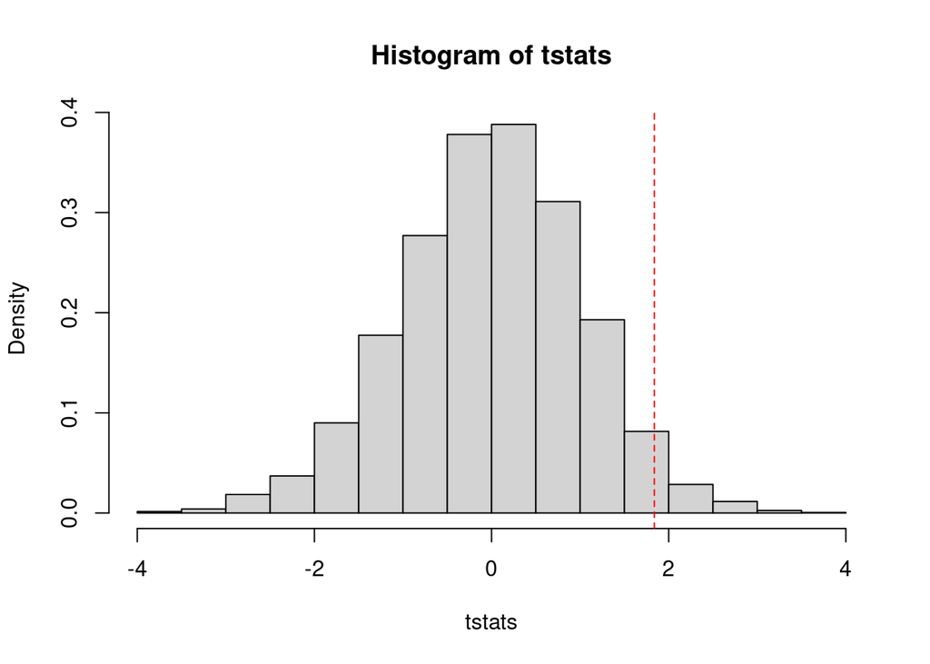

```r
hist(tstats, freq = FALSE)
abline(v=summary(fit)$coef[2,3], lty =2, col= "red")
```

#### (e) Overlay an appropriate t-density over the histogram. Hint: Use grid <- seq(-3, 3, length = 300) to create a grid of values, then use the dt() function to compute the t-density on this grid and the lines() function to superimpose the result.

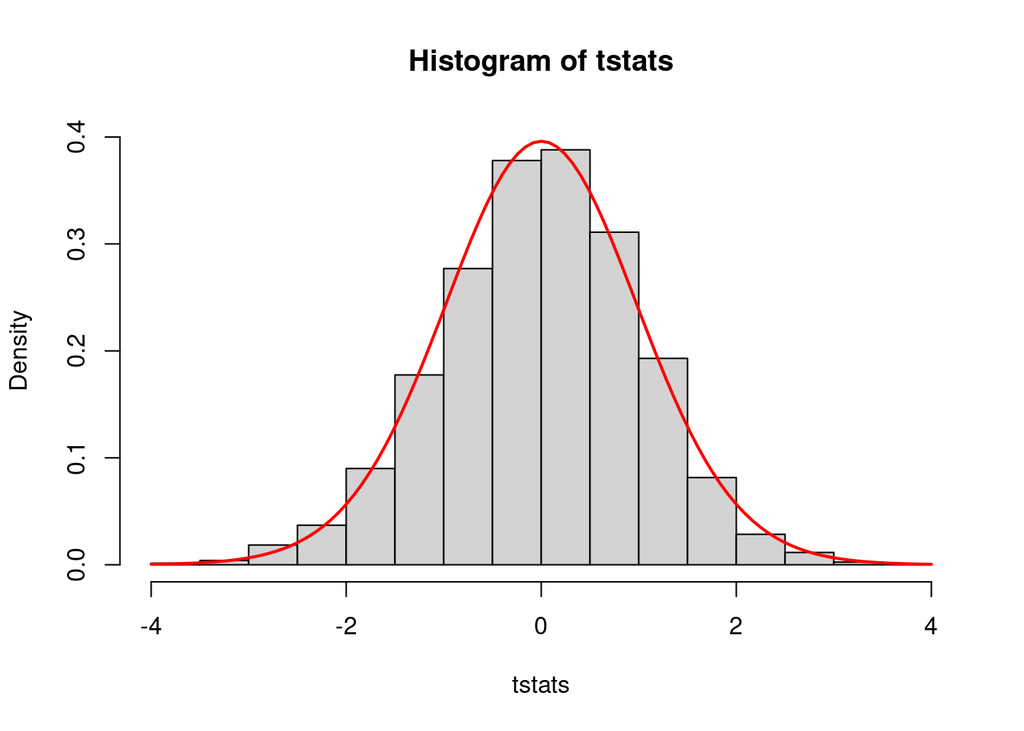

```r
hist(tstats, freq = FALSE, ylim=c(0,0.4))
curve(dt(x,df=34), col="red", lwd=2, add=T)
```

#### (f) Use the bootstrap procedure from Section 3.6 to compute 90 % and 95 % confidence intervals for β money . Does zero fall within these confidence intervals? Are these results consistent with previous tests?

```r
set.seed(123)
nb<-4000
coefmat<- matrix(NA,nb,5)

resids<-residuals(fit)
pred<-fitted(fit)
for(i in 1:nb){
boots<-pred + sample(resids, rep = TRUE)
bmod<-update(fit, boots ~ .)
coefmat[i,]<-coef(bmod)
}

colnames(coefmat) <- c("Intercept", colnames(happy[,2:5]))
quantile(coefmat[,2],c(0.05, 0.95))
```

```
##          5%         95%
## 0.001664199 0.017688209
```

```r
# intervalo de confianza
confint(fit, parm = 2, level=0.9)
```

```
##               5 %      95 %
## money 0.000763349 0.0183928
```

```r
quantile(coefmat[,2],c(0.025,0.975))
```

```
##       2.5%      97.5%
## 0.00019661 0.01909882
```

```r
confint(fit, parm = 2, level = 0.95)
```

```
##              2.5 %     97.5 %
## money -0.001015941 0.02017209
```

Solo con un intervalo de confianza del 95% los calculados con la t-student incluyen al cero, los demás no lo incluyen.

El resultado es consistente, ya que anteriormente, money no quedaba como variable significativa.

### 7. (∗) (Ejercicio 7 cap. 3 pág. 50). In the punting data, we find the average distance punted and hang times of 10 punts of an American football as related to various measures of leg strength for 13 volunteers.

#### (a) Fit a regression model with Distance as the response and the right and left leg strengths and flexibilities as predictors. Which predictors are significant at the 5% level?

```r
require(faraway)
data("punting")
head(punting)
```

```
##   Distance Hang RStr LStr RFlex LFlex   OStr
## 1   162.50 4.75  170  170   106   106 240.57
## 2   144.00 4.07  140  130    92    93 195.49
## 3   147.50 4.04  180  170    93    78 152.99
## 4   163.50 4.18  160  160   103    93 197.09
## 5   192.00 4.35  170  150   104    93 266.56
## 6   171.75 4.16  150  150   101    87 260.56
```

```r
lmod11<-lm(Distance ~ RStr + LStr + RFlex + LFlex, data = punting)
summary(lmod11)
```

```
##
## Call:
## lm(formula = Distance ~ RStr + LStr + RFlex + LFlex, data = punting)
##
## Residuals:
##     Min      1Q  Median      3Q     Max
## -23.941  -8.958  -4.441  13.523  17.016
##
## Coefficients:
##             Estimate Std. Error t value Pr(>|t|)
## (Intercept) -79.6236    65.5935  -1.214    0.259
## RStr          0.5116     0.4856   1.054    0.323
## LStr         -0.1862     0.5130  -0.363    0.726
## RFlex         2.3745     1.4374   1.652    0.137
## LFlex        -0.5277     0.8255  -0.639    0.541
##
## Residual standard error: 16.33 on 8 degrees of freedom
## Multiple R-squared:  0.7365, Adjusted R-squared:  0.6047
## F-statistic:  5.59 on 4 and 8 DF,  p-value: 0.01902
```

```r
lmod11sum<-summary(lmod11)
```

Ninguna de las variables está por debajo de 0.05, con lo cual ninguna sería significativa.

#### (b) Use an F -test to determine whether collectively these four predictors have a relationship to the response.

```r
c(lmod11$fstatistic, p=pf(lmod11sum$fstatistic[1], lmod11sum$fstatistic[2], lmod11sum$fstatistic[3],lower.tail = FALSE))
```

```
##    p.value
## 0.01902482
```

El valor de p es inferior a 0.05 y por la tanto el conjunto de los 4 es significativo.

#### (c) Relative to the model in (a), test whether the right and left leg strengths have the same effect

```r
lmod12<-lm(Distance ~ I(RStr + LStr) + RFlex + LFlex , data = punting)
anova(lmod12,lmod11)
```

```
## Analysis of Variance Table
##
## Model 1: Distance ~ I(RStr + LStr) + RFlex + LFlex
## Model 2: Distance ~ RStr + LStr + RFlex + LFlex
##   Res.Df    RSS Df Sum of Sq      F Pr(>F)
## 1      9 2287.4
## 2      8 2132.6  1    154.72 0.5804  0.468
```

El valor es elevado así que no podemos rechazar la hipótesis de igualdad y la aceptamos

#### (d) Construct a 95% confidence region for (β Str , β LStr ). Explain how the test in (c) relates to this region.

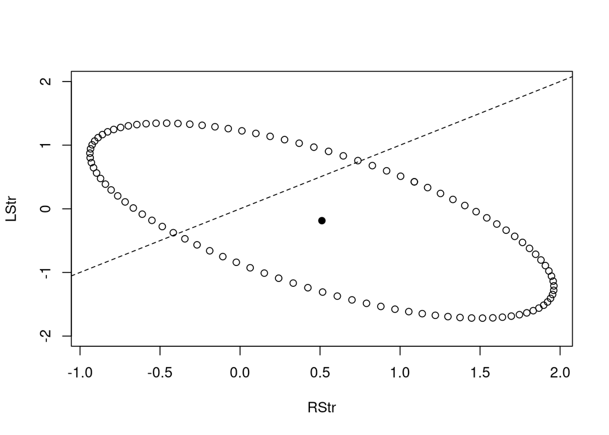

```r
require(ellipse)
plot(ellipse(lmod11,2:3), ylim = -c(2,-2))
points(coef(lmod11)[2], coef(lmod11)[3], pch=19)
abline(0,1,lty=2)
```

la recta corta la elipse, así que no podemos rechazar la hipótesis de que ambos coeficientes tienen la misma influencia.

#### (e) Fit a model to test the hypothesis that it is total leg strength defined by adding the right and left leg strengths that is sufficient to predict the response in comparison to using individual left and right leg strengths.

```r
lmod13<- lm(Distance ~ RStr + LStr, data = punting)
lmod14<- lm(Distance ~ I(RStr + LStr), data=punting)
anova(lmod13,lmod14)
```

```
## Analysis of Variance Table
##
## Model 1: Distance ~ RStr + LStr
## Model 2: Distance ~ I(RStr + LStr)
##   Res.Df    RSS Df Sum of Sq      F Pr(>F)
## 1     10 2973.1
## 2     11 3061.3 -1   -88.281 0.2969 0.5978
```

El modelo con la suma es mejor con los valores individuales.

#### (f) Relative to the model in (a), test whether the right and left leg flexibilities have the same effect.

```r
lmod15<-lm(Distance ~ RStr + LStr + I(RFlex + LFlex), data=punting)
anova(lmod15, lmod11)
```

```
## Analysis of Variance Table
##
## Model 1: Distance ~ RStr + LStr + I(RFlex + LFlex)
## Model 2: Distance ~ RStr + LStr + RFlex + LFlex
##   Res.Df    RSS Df Sum of Sq      F Pr(>F)
## 1      9 2648.4
## 2      8 2132.6  1    515.72 1.9346 0.2017
```

En este caso, tenemos que aceptar la hipótesis de igualdad.

#### (g) Test for left-right symmetry by performing the tests in (c) and (f) simultaneously.

```r
lmod16<- lm(Distance ~ I(RStr + LStr) + I(RFlex + LFlex), data= punting)
anova(lmod16,lmod11)
```

```
## Analysis of Variance Table
##
## Model 1: Distance ~ I(RStr + LStr) + I(RFlex + LFlex)
## Model 2: Distance ~ RStr + LStr + RFlex + LFlex
##   Res.Df    RSS Df Sum of Sq    F Pr(>F)
## 1     10 2799.1
## 2      8 2132.6  2    666.43 1.25  0.337
```

Aceptamos la hipótesis de la simetría

#### (h) Fit a model with Hang as the response and the same four predictors. Can we make a test to compare this model to that used in (a)? Explain.

```r
lmod17<- lm(Hang ~ RStr + LStr + RFlex + LFlex, data = punting)
anova(lmod17,lmod11)
```

```
## Analysis of Variance Table
##
## Response: Hang
##           Df  Sum Sq Mean Sq F value    Pr(>F)
## RStr       1 1.98540 1.98540 30.0416 0.0005867 ***
## LStr       1 0.19827 0.19827  3.0001 0.1214978
## RFlex      1 0.14699 0.14699  2.2241 0.1742114
## LFlex      1 0.00833 0.00833  0.1260 0.7317905
## Residuals  8 0.52871 0.06609
## ---
## Signif. codes:  0 '***' 0.001 '**' 0.01 '*' 0.05 '.' 0.1 ' ' 1
```

Con variables respuesta distintas, no son comparables

## Ejercicios del libro de Carmona

#### 2. (∗) (Ejercicio 5.2 del Capítulo 5 página 86)

Una variable Y depende de otra x (variable control no aleatoria) que toma los valores x1 = 1, x2 = 2, x3 = 3, x4 = 4 de acuerdo con el modelo lineal normal y i = β0 + β1 xi + β2 x²i + ei

Encontrar la expresión del estadístico F para la hipótesis H0 : β2 = 0

```r
# Contruimos la matriz

x<- matrix(c(1,1,1,
1,2,4,
1,3,9,
1,4,16), byrow = T, ncol=3)

# es de rango máximo
qr(x)$rank
```

```
## [1] 3
```

```r
# La resolvemos

imP<-diag(rep(1,4)) - x %*% solve(t(x) %*% x) %*% t(x)

imP
```

```
##       [,1]  [,2]  [,3]  [,4]
## [1,]  0.05 -0.15  0.15 -0.05
## [2,] -0.15  0.45 -0.45  0.15
## [3,]  0.15 -0.45  0.45 -0.15
## [4,] -0.05  0.15 -0.15  0.05
```

```r
# La matriz de la hipótesis nula

x0<-matrix(c(1,1,
1,2,
1,3,
1,4), byrow= T, ncol=2)

ImPH <- diag(rep(1,4)) - x0 %*% solve(t(x0) %*% x0) %*% t(x0)
```

RSS H − RSS = y0 (I − Pω )y − y0 (I − PΩ )y = y0 (PΩ − Pω )y donde I − Pω − (I − PΩ ) = PΩ − P ω es

```r
ImPH - imP
```

```
##       [,1]  [,2]  [,3]  [,4]
## [1,]  0.25 -0.25 -0.25  0.25
## [2,] -0.25  0.25  0.25 -0.25
## [3,] -0.25  0.25  0.25 -0.25
## [4,]  0.25 -0.25 -0.25  0.25
```

#### Ejercicio 5.5

Dado el siguiente modelo lineal normal

β1 + β2 = 6.6 2β1 + β2 = 7.8 −β1 + β2 = 2.1 2β1 − β2 = 0.4

Estudiar si se puede aceptar la hipótesis H0 : β2 = 2β1.

```r
# Construimos la matriz

x<- matrix(c(1,1,
2,1,
-1,1,
2,-1), byrow = T, ncol=2)

# Las respuestas

y<-c(6.6,7.8,2.1,0.4)

# Las betas

betas<- solve(crossprod(x,x), crossprod(x,y))
betas
```

```
##       [,1]
## [1,] 2.090
## [2,] 4.025
```

Estimamos la varianza de los errores

```r
r<- ncol(x)
n<- nrow(x)
ee<-y-x %*% betas
RSS<- sum(ee^2)
(MSE<- RSS/(n-r))
```

```
## [1] 0.24325
```

```r
a<-c(2,-1)
numerador<-t(a) %*% betas
denominador<-sqrt(MSE * t(a) %*% solve(t(x) %*% x) %*% a)
t.est<-numerador/denominador
p.value<-pt(abs(t.est), df= n-r, lower.tail =F) * 2
c(t.est, p.value)
```

```
## [1] 0.3898061 0.7342749
```